# Data Mining Lab 2

Jonathan Kuek

13 October 2015

# 1 Data basics

Question 1.6 on page 57 of OpenIntro  
Q1) 1.6 Stealers, study components. In a study of the relationship between socio-economic class and unethical behavior, 129 University of California undergraduates at Berkeley were asked to identify themselves as having low or high social-class by comparing themselves to others with the most (least) money, most (least) education, and most (least) respected jobs. They were also presented with a jar of individually wrapped candies and informed that the candies were for children in a nearby laboratory, but that they could take some if they wanted. After completing some unrelated tasks, participants reported the number of candies they had taken. It was found that those who were identified as upper-class took more candy than others.  
Identify (a) the cases,  
(b) the variables and their types, and  
(c) the main research question in this study.

Q1a) The cases here are the individual 129 University of California undergraduates at Berkeley who took part in this experiment.

Q1b) The variables identified here are the number of candy each participant took, which is a discrete numerical variable and the self-identification of each student by themselves is a nominal categorical variable.

Q1c) The main research question in this study is studying if socio-economic class and unethical behavior was related. The socio-economic class, as measured by the seld identification survey, is the independent variable and the unethical behavior, as measured by the number of candy each participant took, is the dependent variable.

# 2 Numerical data

Question 1.46 on page 66 of OpenIntro  
Q2) 1.46 Medians and IQRs. For each part, compare distributions (1) and (2) based on their medians and IQRs. You do not need to calculate these statistics; simply state how the medians and IQRs compare. Make sure to explain your reasoning.  
(a)  
(1) 3,5,6,7,9  
(2) 3, 5, 6, 7, 20  
(b)  
(1) 3,5,6,7,9  
(2) 3, 5, 8, 7, 9  
(c)  
(1) 1,2,3,4,5  
(2) 6, 7, 8, 9, 10  
(d)  
(1) 0,10,50,60,100  
(2) 0, 100, 500, 600, 1000

Median is the middle number in a rank ordered distribution while the IQR is the 3rd quartile minus the 1st quartile.

For (a), the median is identical at 6 for 1 and 2 because the middle numbers are identical. The IQR is also the same because it is the 4th number minus the 2nd number in a 5 number sequence, so both 1 and 2 have the same IQR in this case.

For (c), the IQR is the same because even though the four numbers are all different, the actual number is 2 for both IQR because they have a similar difference. The median is different for both distributions because it is a 3 in the first distribution and a 8 in the second distribution.

For (d), the two distributions have a different median because the middle numbers are different. The IQR is also different because the different in 3rd quartile and 1st quartile is larger for the second distribution as compared to the first distribution.

# 3 More numerical data

# 4) Making plots

Look at help(faithful) for information on the faithful data.frame. Use the histogram() function in the lattice package to produce a histogram plot of eruptions. Describe the essential features of this distribution.

```r
library(lattice)
help("faithful")
head(faithful)
```

```
##   eruptions waiting
## 1     3.600      79
## 2     1.800      54
## 3     3.333      74
## 4     2.283      62
## 5     4.533      85
## 6     2.883      55
```

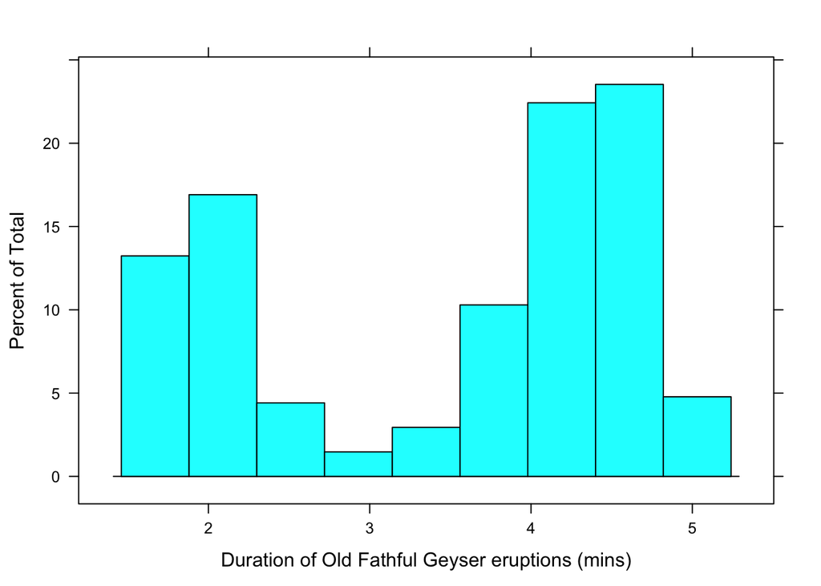

```r
histogram(faithful$eruptions, xlab = "Duration of Old Fathful Geyser eruptions (mins)")
```

We can see from the histogram above that it is a bimodal distribution. 50% of the geyser eruption duration is above 4 minutes and about 30% of the geyser eruption duration is 2 minutes and under. There is no eruption that is less than 1 minute and no eruption that is 6 minutes and above.

# Q5) Stratifying

Put the following line into a chunk in your RMarkdown file

```r
library(dplyr)
cdc <- readRDS(gzcon(url("https://courseworks.columbia.edu/x/Nnry5t")))
head(cdc)
```

```
##     genhlth exerany hlthplan smoke100 height weight wtdesire age gender
## 1      good       0        1        0     70    175      175  77      m
## 2      good       0        1        1     64    125      115  33      f
## 3      good       1        1        1     60    105      105  49      f
## 4      good       1        1        0     66    132      124  42      f
## 5 very good       0        1        0     61    150      130  55      f
## 6 very good       1        1        0     64    114      114  55      f
```

to bring a data.frame called cdc into R whose variables are described here. Use the dplyr package in conjunction with the conditioning variables gender and exerany to calculate the mean and median of the difference between wtdesire and weight for each of the subgroups defined by the intersection of these two conditioning variables. What do you conclude from the results?

```r
difference_of_wtdesire_and_weight <- group_by(cdc, gender, exerany) %>%
  summarize(difference_mean = mean((wtdesire - weight), na.rm = TRUE),
            difference_median = median((wtdesire - weight), na.rm = TRUE))
difference_of_wtdesire_and_weight
```

```
## Source: local data frame [4 x 4]
## Groups: gender [?]
##
##   gender exerany difference_mean difference_median
##   (fctr)   (dbl)           (dbl)             (dbl)
## 1      m       0      -13.897161                -5
## 2      m       1       -9.781941                -5
## 3      f       0      -22.125638               -15
## 4      f       1      -16.593541               -10
```

We can see from the results above that there are four groups when we segment it by gender (sex) and exerany (whether the respondent exercised in the past month or not).

For all groups, we can see that there are negative values for the mean difference between wtdesire (desired weight in pounds) and weight (actual weight in pounds). This would mean that all four groups desire to lose different amount of weight in pounds in order to hit their desired weight targets. We can see that amongst the four groups, those who responded that they exercised in the last month (1) have lower difference mean than their same gender counterparts who did not exercise in the last month. For males who exercised, they are seeking to lose around 9.8 pounds versus males who do not exercise and are looking to lose 13.9 pounds. For females who exercised, they are looking to lose 16.5 pounds versus the 22.1 pounds for females who did not exercise in the last month.

For the median difference, both males who exercised in the last month and did not exercise in the last month have similar values of -5 which is much lower than both the female values of -10 for females who exercised in the last month and -15 for females who did not exercise in the last month.